# Study of AMR

# Definition of the basic model

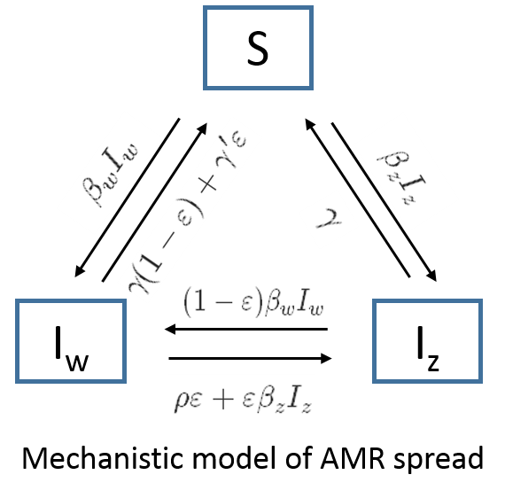

$$\begin{aligned}
\frac{dS}{dt} &=- \beta_w I_wS - \beta_z I_z S + \gamma I_z + \gamma(1 - \varepsilon)I_w + \gamma ` \varepsilon I_w \\
\frac{dI_w}{dt} &=\beta_w I_wS + (1-\varepsilon)\beta_wI_wI_z - \gamma(1 - \varepsilon)I_w - \gamma ` \varepsilon I_w - \varepsilon\beta_zI_zI_w - \rho\varepsilon I_w \\
\frac{dI_z}{dt} &=\beta_z I_zS + \varepsilon\beta_zI_zI_w + \rho\varepsilon I_w - \gamma I_z - (1-\varepsilon)\beta_wI_wI_z \\
\end{aligned}$$

## State variables

| Name of state variable | Description |
| --- | --- |
| $S$ | proportion of population that is susceptible |
| $I_w$ | proportion of population that is infected with sensitive strain |
| $I_z$ | proportion of population that is infected with resistant strain |

## Parameters

[output not shown]

## Additional variables

### Synthetic variables

| Name of synthetic variable | Description | Formula |
| --- | --- | --- |
| $P$ | ratio of resistant prevalence | $P = \frac{I_z}{I_z+I_w}$ |
| $I$ | ratio of resistant incidence | $I = \frac{new I_z}{newI_z+newI_w}$ |

### Antimicrobial consumption

| Name of variable | Description | Formula |
| --- | --- | --- |
| $C$ | drug concentration (per patient per unit of time) |  |
| $AMU$ | antimicrobial usage | $AMU = \varepsilon*C*t$ |
| $Q$ | drug quantity per patient | $Q=C*t$ |
| $\Gamma$ | equivalent drug quantity used in agriculture |  |
| $E$ | drug quantity (in absolute values) | $E=\varepsilon*Q*(I_w+a*I_z)+\Gamma$ |

## Derivatives

$$\begin{aligned}
\frac{dP}{dt} &= P(1-q)\beta_z - P(1-q)[(1-P)\beta_w + P\beta_z] - P(1-P)[\gamma-\left( \gamma(1-\varepsilon)+\gamma'\varepsilon\right)]+(1-P)[-Pq\left((1-\varepsilon)\beta_w-\varepsilon\beta_z\right)+\rho\varepsilon] \\
&= -P(1-q)(1-P)(\beta_w-\beta_z) - P(1-P)[\gamma-\left( \gamma(1-\varepsilon)+\gamma'\varepsilon\right)]+(1-P)[-Pq\left((1-\varepsilon)\beta_w-\varepsilon\beta_z\right)+\rho\varepsilon] \\
\\
\frac{dq}{dt} &= q[(1-q)\left((1-P)\beta_w+P\beta_z)\right) - \gamma - \varepsilon (1-P)(\gamma'-\gamma) ]
\end{aligned}$$

Where:
$$\begin{aligned}
q=I_z+I_w \\
P=\frac{I_z}{I_z+I_w}
\end{aligned}$$

# Steady state exploration

## Steady states when varying $\varepsilon$

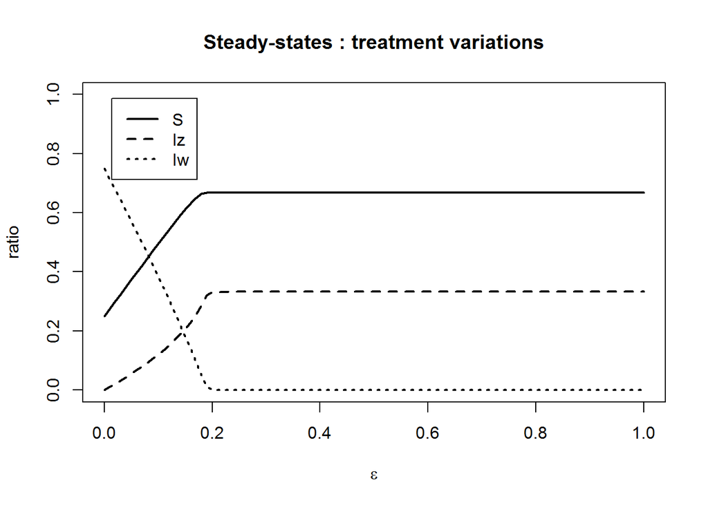

According to our model, the proportions of different populations change for the range of $\varepsilon$ (proportion of treated patients) between 0 and 20%. $I_w$ decreases linearly with the increase of $\varepsilon$. For now on, the behavior of our model will be analyzed for this span of $\varepsilon$ (!! relevance??).

## Steady states when varying $\rho$

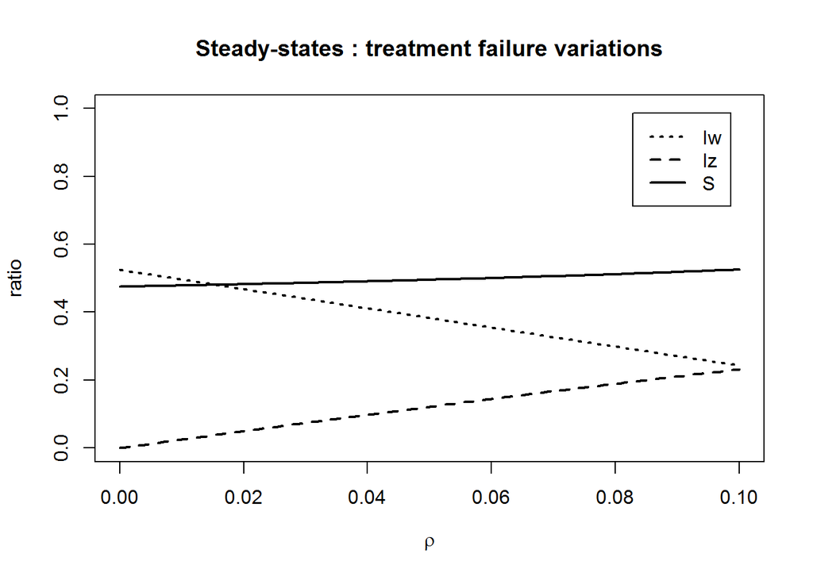

Based on literature, the proportion of treatment failures is between 4 and 8% (add a quote) for tuberculosis. It has a significant impact on the proportion of $I_w$ and $I_z$. When it increases, the prevalence of $I_z$ increases at the expense of $I_w$, while the global burden of the disease decreases. Interestingly, when there is no treatment failure, there is no stable coexistence of sensitive and resistant strains in our model.

## Steady state E when varying $\varepsilon$

We consider Quantity of antibiotics as being the burden of infection multiplied by the proportion of treated patients. In fact, usage of ATB in patients infected with resistant strains does not have any impact on patient’s recovery in our model. Though, here we consider that the ATB are consumed in this subpopulation as well and at the same rate, which may be due to poor or late resistance detection in hospitals or to self-medication in population.

Therefore in this model, $E = (I_w +I_z)*\varepsilon$.

The following plot represents the E in function of $\varepsilon$.

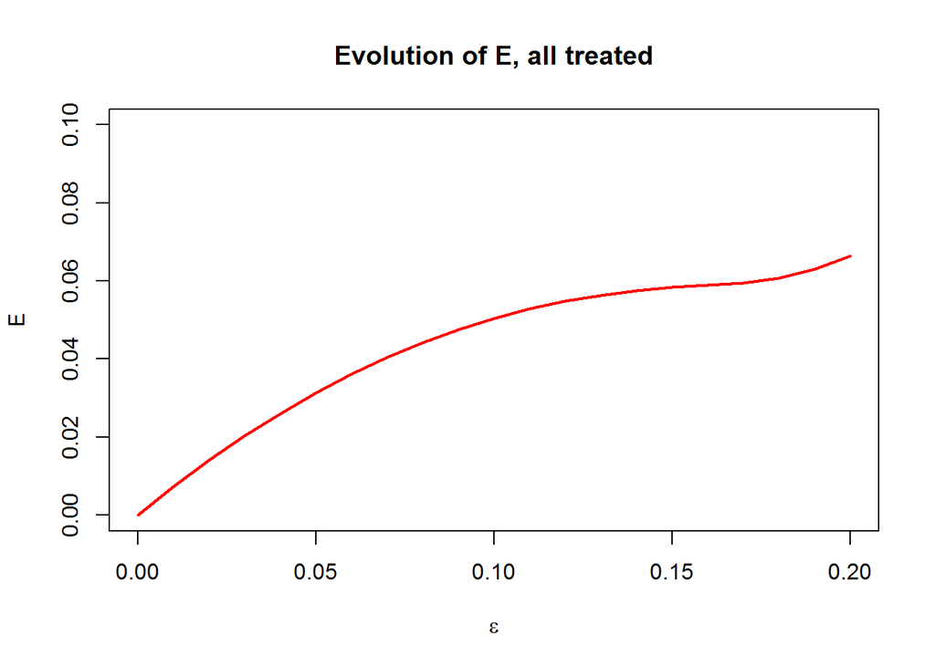

The first part of the graph results from a multiplication of a decreasing linear function ($I_w + I_z$) and an increasing linear function ($\varepsilon$). For extreme values of $\varepsilon$, there is a linear relation between $E$ and $\varepsilon$ as $I_w + I_z$ reaches stability.

This means that at steady states, with nearly the same quantity of antibiotics $E$ (0.05 and 0.06) nearly a double proportion of patients can be treated (10% and 17%).

## Steady state net flow in the model

The steady state flows from one population to another are followed for $\varepsilon$ varying between 0 and 20%.

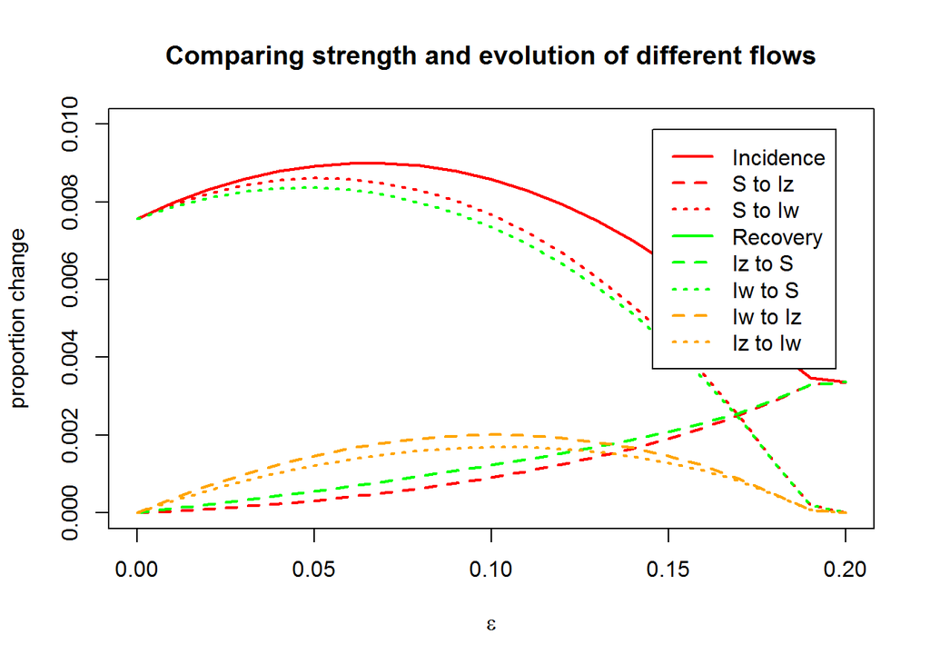

| Flow | Comparison | Flow |
| --- | --- | --- |
| $S$ to $I_w$ | > | $I_w$ to $S$ |
| $I_w$ to $I_z$ | > | $I_z$ to $I_w$ |
| $S$ to $I_z$ | < | $I_z$ to $S$ |

Therefore the net flow in our model is the following:

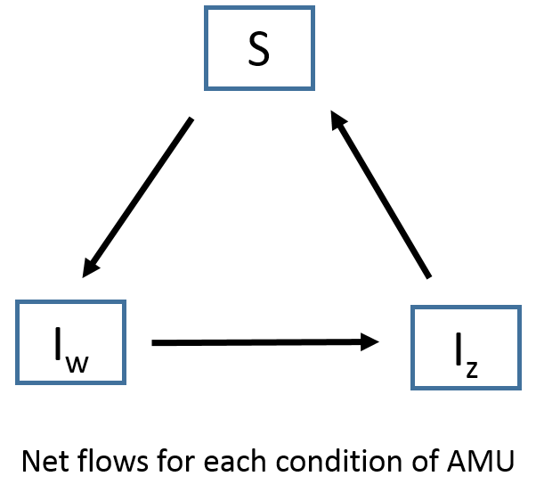

## Steady state resistance ratio P and burden of resistance

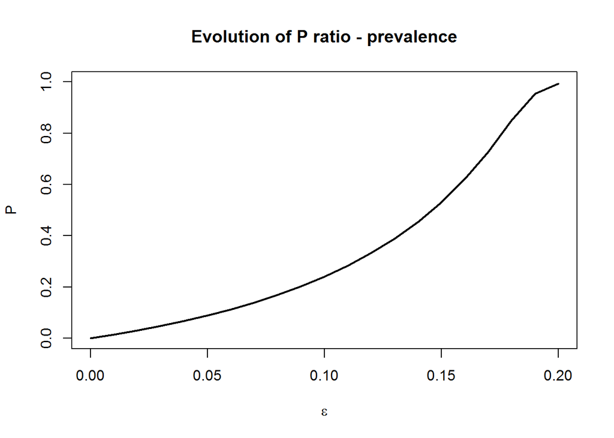

Here, the P corresponds to the ratio of resistant prevalence at steady-states. Usually, it is used in the studies of tuberculosis (WHO 2002). Its exponential growth is due to the interplay of increasing $I_z$ and decreasing $I_w$.

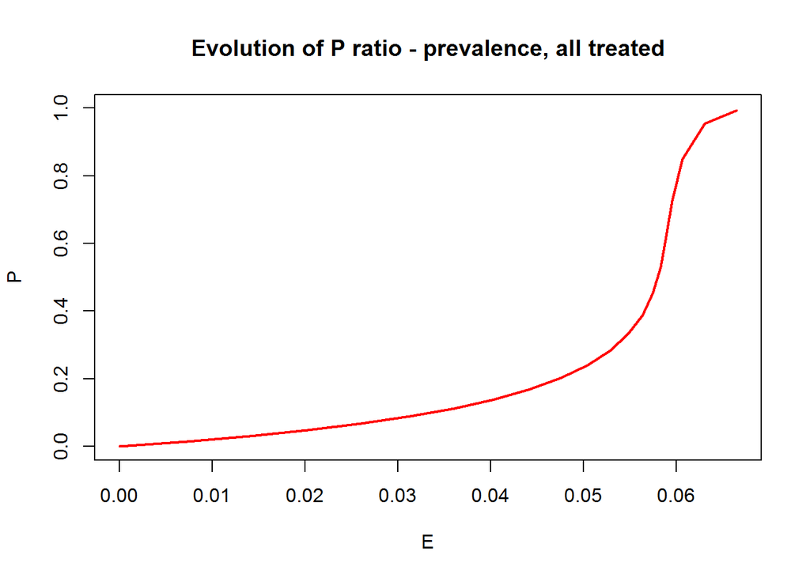

P, the ratio of resistant prevalence, as a function of E shows an exponential growth with saturation, which is due to :

1. interplay of increasing $I_z$ and decreasing $I_w$ with increasing $\varepsilon$
2. saturation part of the curve of Q=f($\varepsilon$) ([0.050, 0.06] of $E$ corresponds to [10%,17%] of $\varepsilon$)

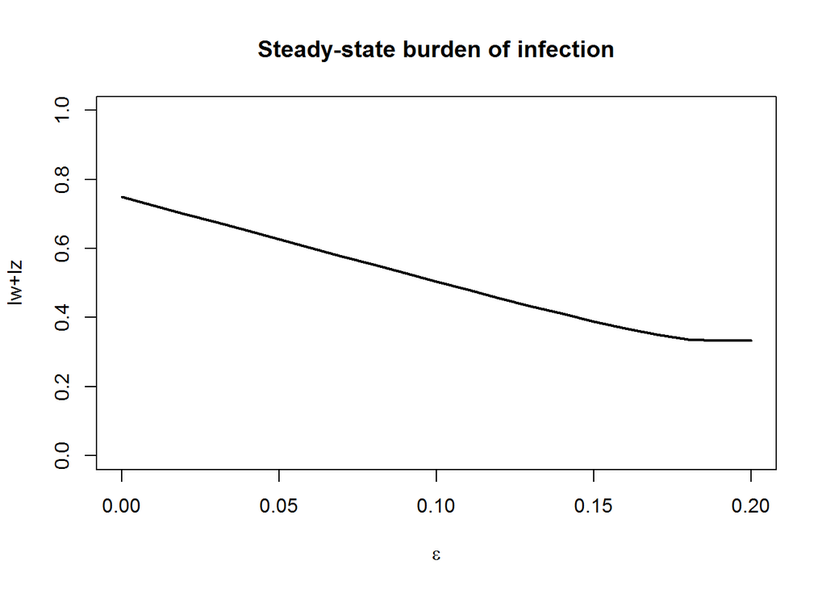

Here, the burden of infection corresponds to the total proportion of infected people. It decreases linearly as the $\varepsilon$ increases, due to the decrease of $I_w$ that is faster than the increase of $I_z$.

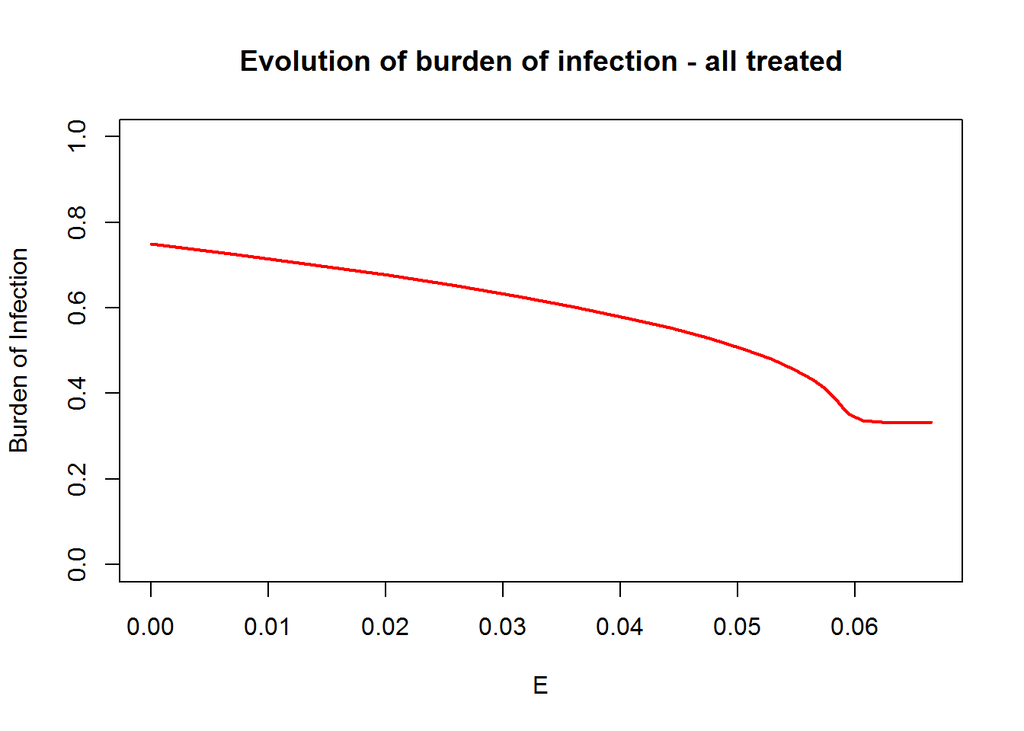

Finally, when plotting the BOI in function of E, decreasing tendency is preserved. Before reaching a stability, there is a fastening decrease of BOI, which is once again due to the saturation tendancy in $E$=f($\varepsilon$).

## Steady state incidence

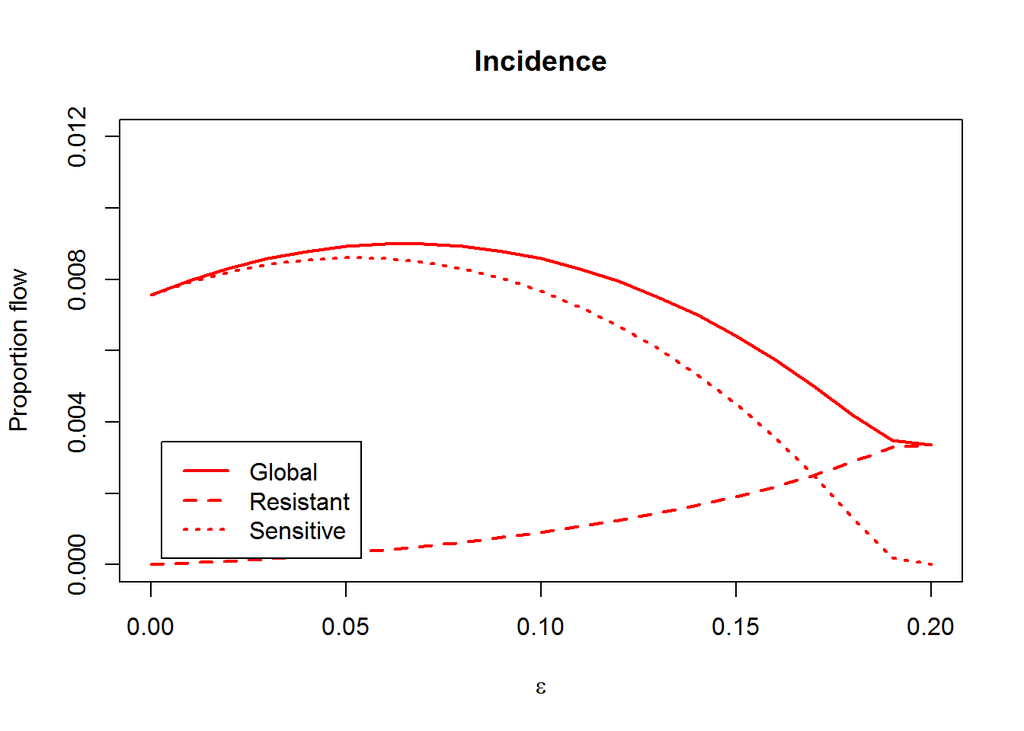

Though the burden of infection decreases linearly with the use of antibiotics, the global incidence evolves in a more complex way. There is a peak for incidence when app. 7% of the patients are treated.

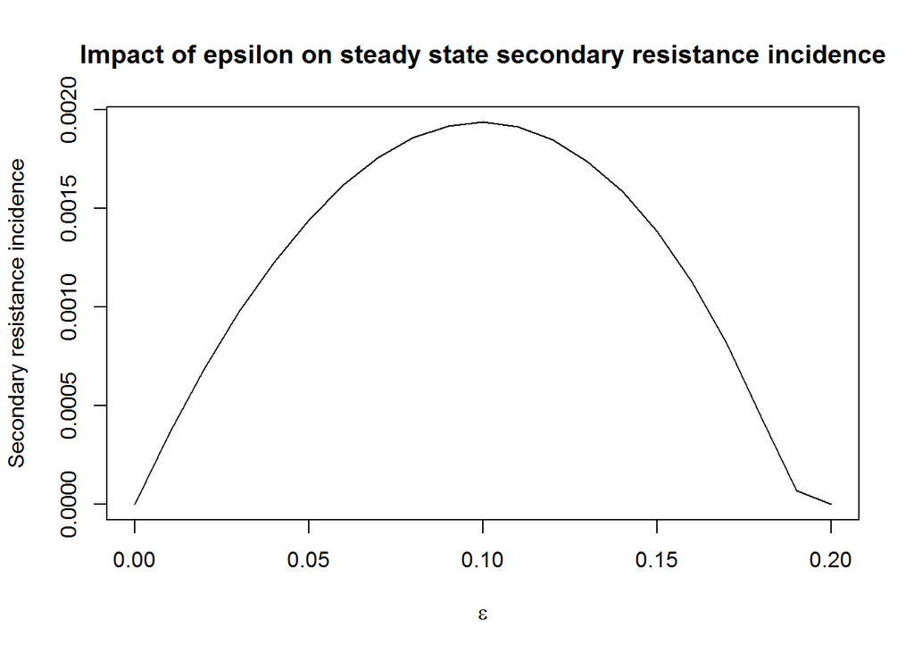

The situation where resistance emerges in a treated patient, comprehending a horizontal tranfer of AMR, $de$ $novo$ mutations and minor resistant population outcompeting its sensitive fellows, is called secondary resistance.

This resistance is represented in our model as a flow from $I_w$ to $I_z$ depending on the $\varepsilon$ and probability of acquiring resistance when treated. As we can see, it reaches a peak for 10% $\varepsilon$. For higher values of $\varepsilon$, the deterioration of $I_w$ population makes the secondary resistance plummet.

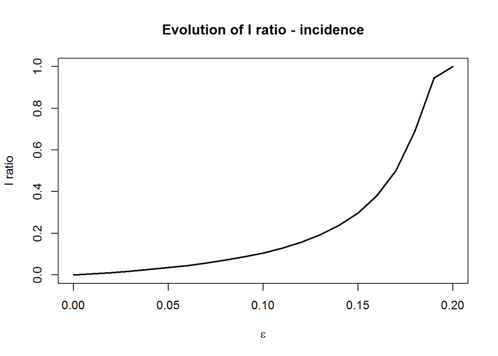

When relating I and Q, the proportion of resistant cases among new cases increases very steeply at higher values (0.050 ti 0.060) of E. This is once again due to:

1. exponential increase in P=f($\varepsilon$)
2. relative steadiness in E=f($\varepsilon$) for higher values of $\varepsilon$ (10 - 17%)

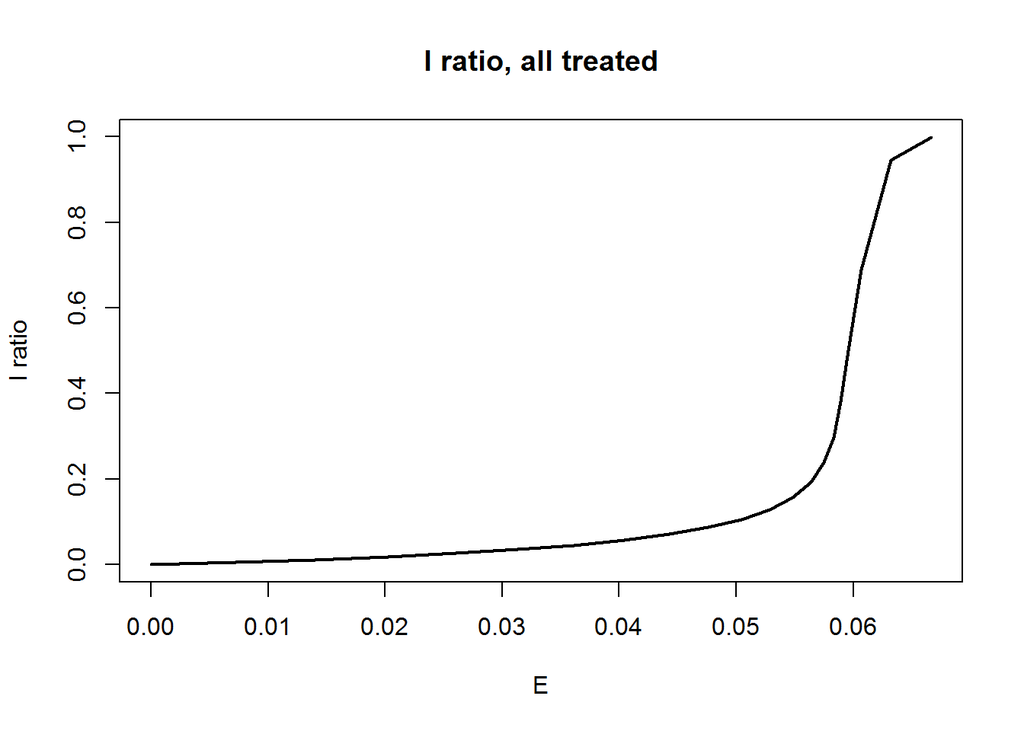

## Average duration of sensitive infection (without resistant dynamics)

In fact, as the $\varepsilon$ varies, so does the average or expected duration of sensitive infection. Increasing $\varepsilon$ will have for an effect more rapid recovery of sensitive cases. Here, we represent the average duration as a function of $\varepsilon$ following this formula :

$$Duration = \frac {1}{((1-\varepsilon)*\gamma + \varepsilon*\gamma')}$$

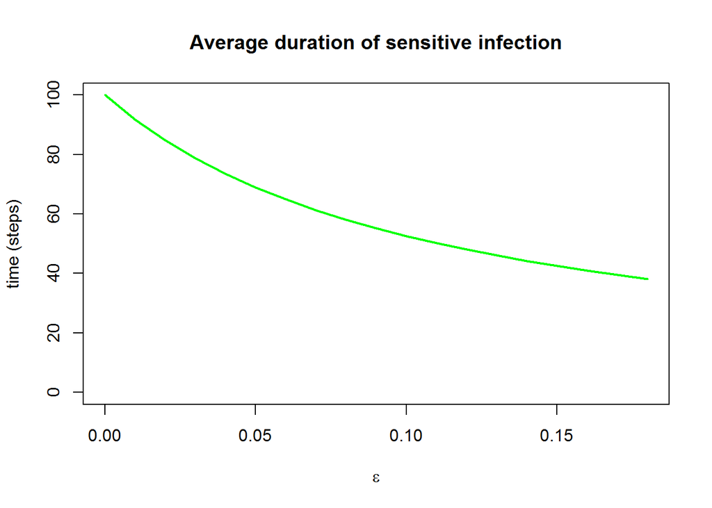

# Dynamics exploitation

In this part, we analyse the dynamics in our model. At time $t=0$, the steady state for $\varepsilon=10%$ was reached. Afterwards, the $\varepsilon$ changes to values between 0% and 20%.

## Dynamics of P after a change in $\varepsilon$

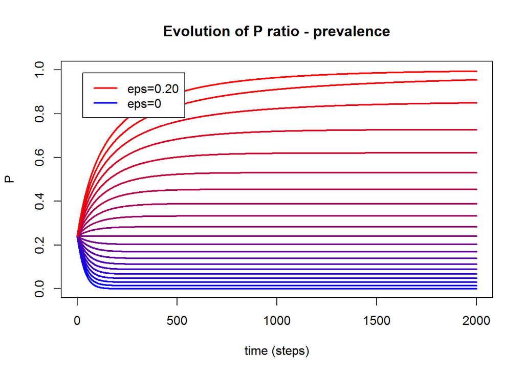

Here, P corresponds to the ratio of resistant prevalence and burden of infection. As the study of its dynamics show, it changes following $\varepsilon$.

## Dynamics of Incidence

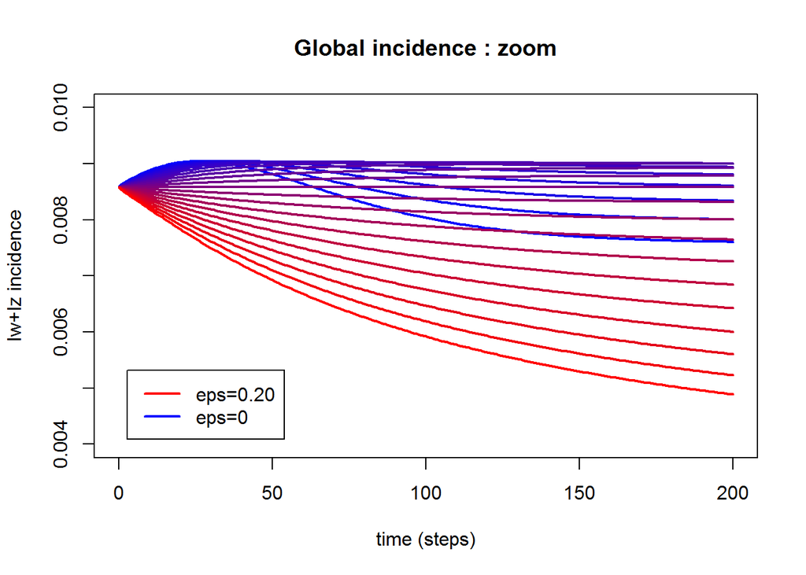

We have seen that at steady state the global incidence increases in the interval of 0% to 7% $\varepsilon$. This means that paradoxically, there are more new infections with higher level of $\varepsilon$.

Here, we see that in short-term dynamics, the incidence depends strongly on $\varepsilon$ : when $\varepsilon$ decreases the global incidence increases for each value of $\varepsilon$.

There is therefore a transient period, that follows a decrease in $\varepsilon$, during which the incidence is higher not only than at the prior state but than at equilibrium as well.

On following paragraphs, we will study the cause of this anti-honeymoon period, during which the incidence is strikingly higher than at equilibrium or at the state prior to $\varepsilon$ reduction.

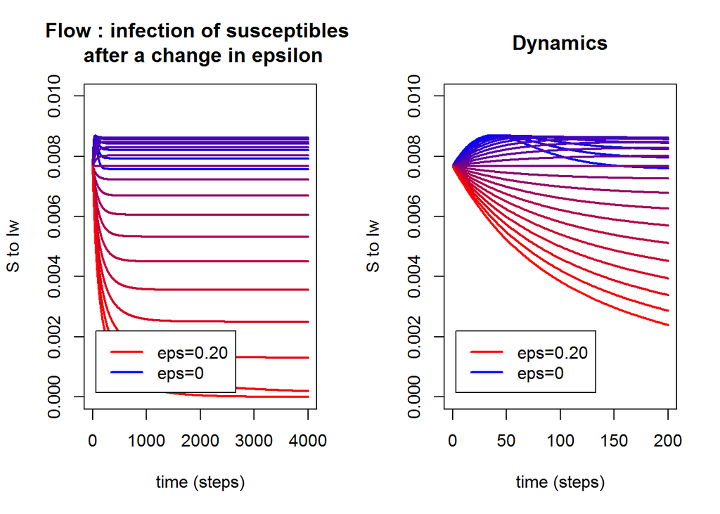

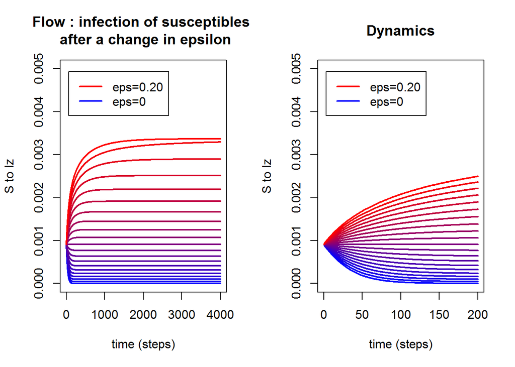

It is indeed the increase in the incidence of sensitive cases that seems to be responsible for the anti-honeymoon period after an abrupt reduction of $\varepsilon$.

The susceptible incidence depends on mass product of $I_w$ and $S$.

We consider now a simpler model with only $I_w$ and $S$ populations, related with the same relationships as in our model. Do these short-term peaks in $I_w$ incidence appear as well? If it is so, the anti-honeymoon period is due only to the interplay between $I_w$ and $S$ when the $\varepsilon$ is suddenly decreased. The second possibility is that the transient anti-honeymoon period is due to the interplay between $I_w$ and $I_z$.

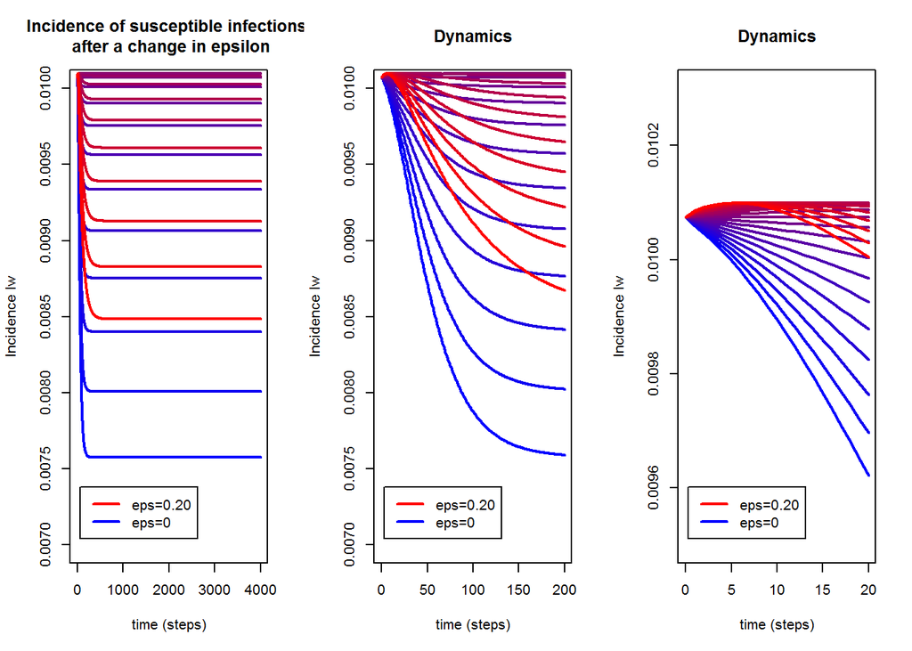

Anti-honeymoon period does not appear in a simpler model and thus this phenomenon emerges due to the presence of $I_z$.

As the sensitive incidence, and thus the anti-honeymoon period, are directly dependent on the mass-product of $I_w$ and $S$, a change in flow between $I_z$ and $I_w$ may have a direct impact on the mass product. In particular, the secondary resistance may be the cause of the short-term peaks as the variation of $\varepsilon$ has a huge and immediate impact on its strength : the decrease of $\varepsilon$ would decrease this flow and we would see a fast accumulation in $I_w$ population at the cost of $I_z$.

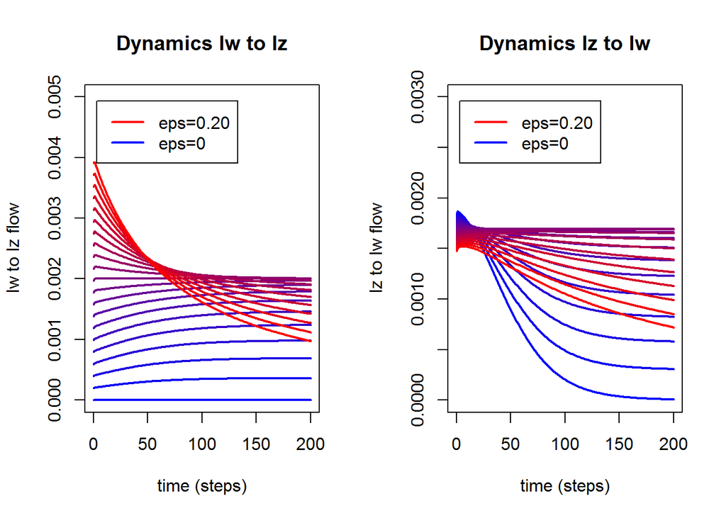

Concurrently to the presence of short-term peaks, the $I_w$ to $I_z$ flow, corresponding to the spread of resistance in infected cases, plummets. In fact, the decrease of $\varepsilon$ has an immediate effect on this flow. Meanwhile the impact on the loss of resistance ($I_z$ to $I_w$ flow) is slower : it reaches the minimum value by the 150th step.

Finally, dynamics in recovery of infected cases may contribute as well to the anti-honeymoon period : as the $\varepsilon$ is suddenly decreased, the expectancy of duration spent in $I_w$ population should increase. This would then transiently promote the accumulation of sensitive cases and therefore the possibility of transmission.

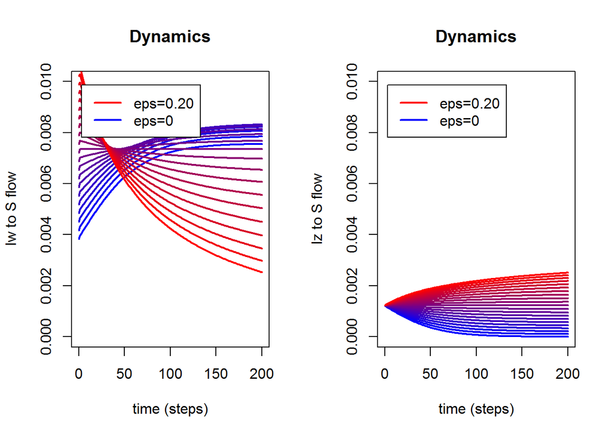

As we can see, the recovery dynamics of sensitive cases after a sudden decrease of $\varepsilon$ is in accordance with our hypothesis and contribute to the anti-honeymoon effect.

The anti-honeymoon effect, following an abrupt drop in $\varepsilon$, is a consequence of several phenomena:

1. The flow from $I_w$ to $I_z$ is suddenly cut, while the flow in opposite direction slows down progressively, resulting in a redistribution of infected cases.
2. The average duration of sensitive infection becomes longer, resulting in accumulation of sensitive cases.
3. As a result of the accumulation of sensitive cases, the mass product of $S$ and $I_w$ increases. In consequence, the $S$ is transiently drawn by $I_w$.

Finally, we represent here the net flows between the three subpopulations after a change in $\varepsilon$:

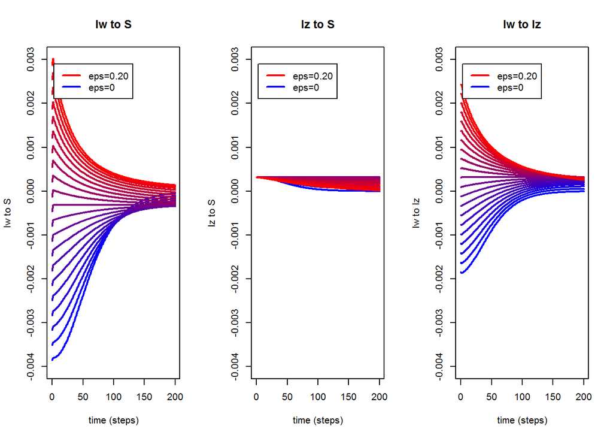

We can notice that $I_w$ to $S$ and $I_w$ and $I_z$ net flows are discontinuous because some of their components ($I_w$ to $S$, $I_w$ to $I_z$ and $I_z$ to $I_w$ flows) depend directly on $\varepsilon$ changing abruptly at t=0. On the otherhand $I_z$ to $S$ net flow is continuous because each of its components is independent on $\varepsilon$.

During short-time period after a sharp decrease in $\varepsilon$, the net flows in our model are as follows:

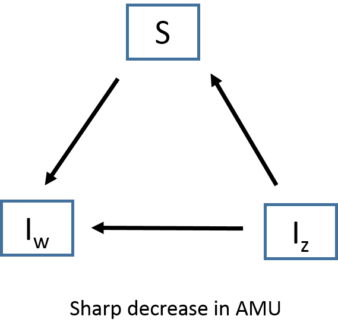

At sharp increase of $\varepsilon$ the net flows in our model change as well:

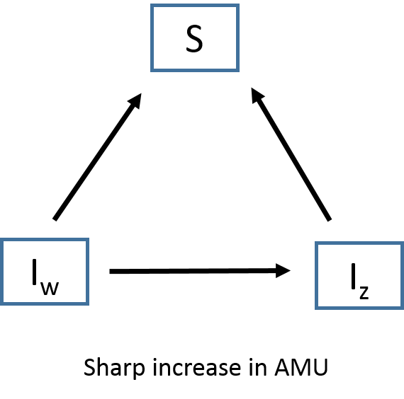

# Inhibition of certain functions in our model

## Inhibition of interhost competition

To inhibit the interhost competition in our model, $\beta_z$ takes the value of $0.4$ that is to say becomes equal to $\beta_w$. The intrahost competition remains, although it depends on $\beta_z$ $via$ the probability of superinfection.

The steady state values of state variables are the following:

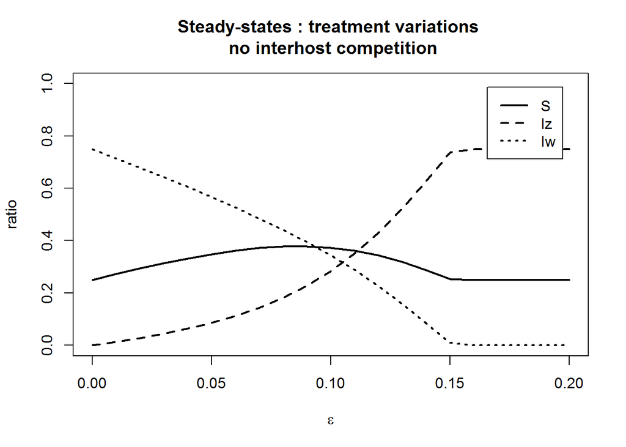

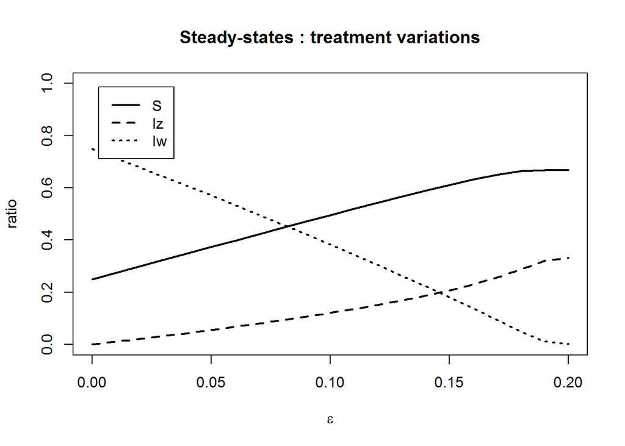

We observe thus coexistence of the strains for values of $\varepsilon$ between approximately 0 and 15%. When $I_z$ is fixed, it has the same value as $I_z$ prevalence during prebiotic era.

Interestingly, when no ATB is used, resistant strain does not coexist with the sensitive one due to indirect cost linked to co-infections. Although no direct cost of resistance is included in this particular model, when resistant cases are reinfected with sensitive strains, the sensitive strain prevails.

Paradoxically the prevalence has the lowest value for $\varepsilon$ of 10% due to indirect competition. The incidence is highest at the same time as the turnover of sensitive cases is highest (we observe a peak of $I_w$ and $S$ mass product). It returns to pre-antibiotic era as $I_z$ becomes fixed.

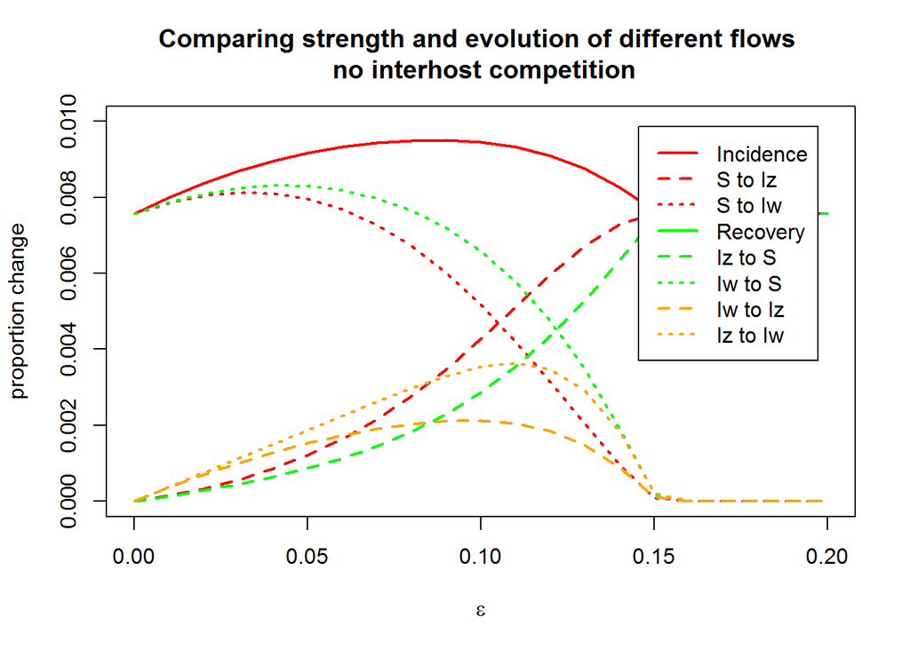

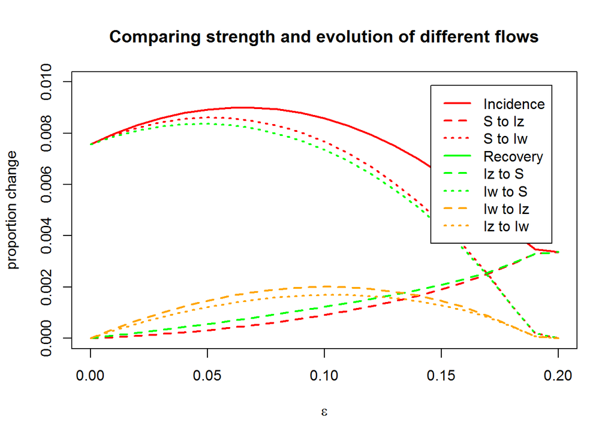

As there is no cost of resistance, the interplay between resistant and sensitive strain will depend solely on $\varepsilon$ and $\rho$. As $\varepsilon$, that corresponds to the $\varepsilon$ here, increases, a higher turnover of sensitive cases occurs, while the flow from $I_w$ to $I_z$ increases at the expense of $I_z$ to $I_w$ flow.